# Projet_Actuariat

# Application de ChainLadder (Question 4 et partie de la question 5 : nombre de tardifs)

C’est la méthode déterministe la plus courrante et la plus connue.  
Cette méthodes impliques deux fortes hypothèses:  
• Les sinistres sont déclarés et payés au même rythme quelle que soit  
l’année de survenance.  
• Le développement des sinistres est régulier.  
## Triangles d’ouvertures

```r
cl_ouv=chainladder(tri_ouv_cum)
facteurs=numeric()
fnames=c()
for (i in 1:9){
  fnames[i]=paste0('f',i)
  facteurs[i]=cl_ouv$Models[[i]]$coefficient
}
facteurs_dev=setNames(facteurs, fnames)
facteurs_dev
```

```
##       f1       f2       f3       f4       f5       f6       f7       f8
## 1.057810 1.004481 1.001607 1.000310 1.000146 1.000055 1.000038 1.000000
##       f9
## 1.000000
```

à partir de ces facteurs de développements on va calculer la partie vide inférieure du triangle.

```r
tri_ouv_cum_full=predict(cl_ouv)
tri_ouv_cum_full
```

```
##       dev
## origin     1       2        3        4        5        6        7        8
##   2005 31116 33092.0 33280.00 33344.00 33356.00 33360.00 33360.00 33362.00
##   2006 31198 33120.0 33246.00 33282.00 33294.00 33298.00 33298.00 33298.00
##   2007 35850 37760.0 37892.00 37948.00 37960.00 37970.00 37974.00 37976.00
##   2008 37860 39864.0 40004.00 40066.00 40074.00 40078.00 40082.00 40083.53
##   2009 31142 33112.0 33290.00 33352.00 33358.00 33362.00 33363.84 33365.12
##   2010 32930 34724.0 34908.00 34948.00 34964.00 34969.11 34971.04 34972.38
##   2011 36808 38638.0 38824.00 38908.00 38920.06 38925.74 38927.89 38929.38
##   2012 37568 39790.0 39956.00 40020.20 40032.60 40038.45 40040.66 40042.19
##   2013 37966 40400.0 40581.04 40646.24 40658.84 40664.78 40667.03 40668.58
##   2014 36480 38588.9 38761.83 38824.11 38836.14 38841.81 38843.96 38845.45
##       dev
## origin        9       10
##   2005 33362.00 33362.00
##   2006 33298.00 33298.00
##   2007 37976.00 37976.00
##   2008 40083.53 40083.53
##   2009 33365.12 33365.12
##   2010 34972.38 34972.38
##   2011 38929.38 38929.38
##   2012 40042.19 40042.19
##   2013 40668.58 40668.58
##   2014 38845.45 38845.45
```

On extrait le nombre d’ouvertures connu pour chaque année (qui représente la diagonale du triangle d’ouverture cumulé) et on l’ajoute au triangle

```r
Diagonale=numeric()
for (i in 1:n){
  for (j in 1:n){
    if (i+j==11)
      Diagonale[i]=tri_ouv_cum_full[i,j]
  }
}
tri_ouv_cum_full=cbind(tri_ouv_cum_full,Diagonale)
tri_ouv_cum_full
```

```
##          1       2        3        4        5        6        7        8
## 2005 31116 33092.0 33280.00 33344.00 33356.00 33360.00 33360.00 33362.00
## 2006 31198 33120.0 33246.00 33282.00 33294.00 33298.00 33298.00 33298.00
## 2007 35850 37760.0 37892.00 37948.00 37960.00 37970.00 37974.00 37976.00
## 2008 37860 39864.0 40004.00 40066.00 40074.00 40078.00 40082.00 40083.53
## 2009 31142 33112.0 33290.00 33352.00 33358.00 33362.00 33363.84 33365.12
## 2010 32930 34724.0 34908.00 34948.00 34964.00 34969.11 34971.04 34972.38
## 2011 36808 38638.0 38824.00 38908.00 38920.06 38925.74 38927.89 38929.38
## 2012 37568 39790.0 39956.00 40020.20 40032.60 40038.45 40040.66 40042.19
## 2013 37966 40400.0 40581.04 40646.24 40658.84 40664.78 40667.03 40668.58
## 2014 36480 38588.9 38761.83 38824.11 38836.14 38841.81 38843.96 38845.45
##             9       10 Diagonale
## 2005 33362.00 33362.00     33362
## 2006 33298.00 33298.00     33298
## 2007 37976.00 37976.00     37976
## 2008 40083.53 40083.53     40082
## 2009 33365.12 33365.12     33362
## 2010 34972.38 34972.38     34964
## 2011 38929.38 38929.38     38908
## 2012 40042.19 40042.19     39956
## 2013 40668.58 40668.58     40400
## 2014 38845.45 38845.45     36480
```

On ajoute le nombre ultime (nombre d’ouvertures probables pour les sinistres d’années de survenance i)

```r
#on ajoute le round juste pour avoir un nombre entier car celui-ci représente un nobmre d'ouvertures
Nb_Ultime=round(tri_ouv_cum_full[,10]-tri_ouv_cum_full[,'Diagonale'])
tri_ouv_cum_full=cbind(tri_ouv_cum_full,Nb_Ultime)
tri_ouv_cum_full
```

```
##          1       2        3        4        5        6        7        8
## 2005 31116 33092.0 33280.00 33344.00 33356.00 33360.00 33360.00 33362.00
## 2006 31198 33120.0 33246.00 33282.00 33294.00 33298.00 33298.00 33298.00
## 2007 35850 37760.0 37892.00 37948.00 37960.00 37970.00 37974.00 37976.00
## 2008 37860 39864.0 40004.00 40066.00 40074.00 40078.00 40082.00 40083.53
## 2009 31142 33112.0 33290.00 33352.00 33358.00 33362.00 33363.84 33365.12
## 2010 32930 34724.0 34908.00 34948.00 34964.00 34969.11 34971.04 34972.38
## 2011 36808 38638.0 38824.00 38908.00 38920.06 38925.74 38927.89 38929.38
## 2012 37568 39790.0 39956.00 40020.20 40032.60 40038.45 40040.66 40042.19
## 2013 37966 40400.0 40581.04 40646.24 40658.84 40664.78 40667.03 40668.58
## 2014 36480 38588.9 38761.83 38824.11 38836.14 38841.81 38843.96 38845.45
##             9       10 Diagonale Nb_Ultime
## 2005 33362.00 33362.00     33362         0
## 2006 33298.00 33298.00     33298         0
## 2007 37976.00 37976.00     37976         0
## 2008 40083.53 40083.53     40082         2
## 2009 33365.12 33365.12     33362         3
## 2010 34972.38 34972.38     34964         8
## 2011 38929.38 38929.38     38908        21
## 2012 40042.19 40042.19     39956        86
## 2013 40668.58 40668.58     40400       269
## 2014 38845.45 38845.45     36480      2365
```

```r
Total_ouv=sum(tri_ouv_cum_full[,12])
print('Total ouvertures des sinistres survenues entre 2005 - 2014 tardifs (avec n=9) :')
```

```
## [1] "Total ouvertures des sinistres survenues entre 2005 - 2014 tardifs (avec n=9) :"
```

```r
Total_ouv
```

```
## [1] 2754
```

## Triangle de règlements

On refait eactement le mème travail que celui du triangle d’ouvertures

```r
cl_reg=chainladder(tri_reg_cum)
facteurs=numeric()
fnames=c()
for (i in 1:9){
  fnames[i]=paste0('f',i)
  facteurs[i]=cl_reg$Models[[i]]$coefficient
}
facteurs_dev=setNames(facteurs, fnames)
facteurs_dev
```

```
##       f1       f2       f3       f4       f5       f6       f7       f8
## 4.548160 1.241690 1.066405 1.027110 1.014423 1.005829 1.014204 1.000685
##       f9
## 1.002942
```

```r
tri_reg_cum_full=predict(cl_reg)
tri_reg_cum_full
```

```
##       dev
## origin       1        2        3        4        5        6        7        8
##   2005  932885  4170108  5178742  5895583  6101205  6142992  6201206  6339425
##   2006  754417  3466602  5314858  5765461  5929663  6059290  6091617  6149260
##   2007  978419  5103958  6778747  7246934  7464958  7583027  7609862  7696706
##   2008 1316441  6021787  7555658  8053228  8327443  8449896  8497101  8617797
##   2009 1515114  7237753  8623382  9198259  9396273  9521143  9576641  9712672
##   2010 2228111  8471438 10040083 10577748 10784701 10940245 11004015 11160321
##   2011 2444956 10146801 12415451 12882218 13231451 13422284 13500521 13692288
##   2012 2270648 11959204 14344968 15297548 15712260 15938873 16031779 16259501
##   2013 2591382 11791984 14641986 15614290 16037588 16268893 16363723 16596160
##   2014 2045751  9304403 11553181 12320372 12654374 12836884 12911709 13095112
##       dev
## origin        9       10
##   2005  6340572  6359226
##   2006  6156665  6174778
##   2007  7701977  7724636
##   2008  8623699  8649070
##   2009  9719323  9747917
##   2010 11167963 11200820
##   2011 13701664 13741975
##   2012 16270636 16318504
##   2013 16607525 16656384
##   2014 13104080 13142632
```

```r
Diagonale=numeric()
for (i in 1:n){
  for (j in 1:n){
    if (i+j==11)
      Diagonale[i]=tri_reg_cum_full[i,j]
  }
}
tri_reg_cum_full=cbind(tri_reg_cum_full,Diagonale)
tri_reg_cum_full
```

```
##            1        2        3        4        5        6        7        8
## 2005  932885  4170108  5178742  5895583  6101205  6142992  6201206  6339425
## 2006  754417  3466602  5314858  5765461  5929663  6059290  6091617  6149260
## 2007  978419  5103958  6778747  7246934  7464958  7583027  7609862  7696706
## 2008 1316441  6021787  7555658  8053228  8327443  8449896  8497101  8617797
## 2009 1515114  7237753  8623382  9198259  9396273  9521143  9576641  9712672
## 2010 2228111  8471438 10040083 10577748 10784701 10940245 11004015 11160321
## 2011 2444956 10146801 12415451 12882218 13231451 13422284 13500521 13692288
## 2012 2270648 11959204 14344968 15297548 15712260 15938873 16031779 16259501
## 2013 2591382 11791984 14641986 15614290 16037588 16268893 16363723 16596160
## 2014 2045751  9304403 11553181 12320372 12654374 12836884 12911709 13095112
##             9       10 Diagonale
## 2005  6340572  6359226   6359226
## 2006  6156665  6174778   6156665
## 2007  7701977  7724636   7696706
## 2008  8623699  8649070   8497101
## 2009  9719323  9747917   9521143
## 2010 11167963 11200820  10784701
## 2011 13701664 13741975  12882218
## 2012 16270636 16318504  14344968
## 2013 16607525 16656384  11791984
## 2014 13104080 13142632   2045751
```

```r
Nb_Ultime=round(tri_reg_cum_full[,10]-tri_reg_cum_full[,'Diagonale'])
tri_reg_cum_full=cbind(tri_reg_cum_full,Nb_Ultime)
tri_reg_cum_full
```

```
##            1        2        3        4        5        6        7        8
## 2005  932885  4170108  5178742  5895583  6101205  6142992  6201206  6339425
## 2006  754417  3466602  5314858  5765461  5929663  6059290  6091617  6149260
## 2007  978419  5103958  6778747  7246934  7464958  7583027  7609862  7696706
## 2008 1316441  6021787  7555658  8053228  8327443  8449896  8497101  8617797
## 2009 1515114  7237753  8623382  9198259  9396273  9521143  9576641  9712672
## 2010 2228111  8471438 10040083 10577748 10784701 10940245 11004015 11160321
## 2011 2444956 10146801 12415451 12882218 13231451 13422284 13500521 13692288
## 2012 2270648 11959204 14344968 15297548 15712260 15938873 16031779 16259501
## 2013 2591382 11791984 14641986 15614290 16037588 16268893 16363723 16596160
## 2014 2045751  9304403 11553181 12320372 12654374 12836884 12911709 13095112
##             9       10 Diagonale Nb_Ultime
## 2005  6340572  6359226   6359226         0
## 2006  6156665  6174778   6156665     18113
## 2007  7701977  7724636   7696706     27930
## 2008  8623699  8649070   8497101    151969
## 2009  9719323  9747917   9521143    226774
## 2010 11167963 11200820  10784701    416119
## 2011 13701664 13741975  12882218    859757
## 2012 16270636 16318504  14344968   1973536
## 2013 16607525 16656384  11791984   4864400
## 2014 13104080 13142632   2045751  11096881
```

```r
Total_reg=sum(tri_reg_cum_full[,12])
print(paste('Total règlements des sinistres survenues entre 2005 - 2014 et qui ne sont pas ouverts durant cette même période: ',Total_reg))
```

```
## [1] "Total règlements des sinistres survenues entre 2005 - 2014 et qui ne sont pas ouverts durant cette même période:  19635479"
```

## Triangle des charges

Cette fois-ci on refait le travail avec le triangle des charges (règlements + provisions)

```r
cl_charges=chainladder(tri_charges_cum)
facteurs=numeric()
fnames=c()
for (i in 1:9){
  fnames[i]=paste0('f',i)
  facteurs[i]=cl_charges$Models[[i]]$coefficient
}
facteurs_dev=setNames(facteurs, fnames)
facteurs_dev
```

```
##       f1       f2       f3       f4       f5       f6       f7       f8
## 1.902625 1.259724 1.092608 1.064943 1.051621 1.040835 1.029817 1.024211
##       f9
## 1.022555
```

```r
tri_charges_cum_full=predict(cl_charges)
tri_charges_cum_full
```

```
##       dev
## origin        1        2        3        4        5        6        7        8
##   2005  9507579 18084094 23563822 26582075 28015301 29165522 30244342 31186479
##   2006 10035217 18258678 23958894 25699979 26894825 27844540 28573215 29388408
##   2007 11648405 22659418 28868865 31481312 33714036 35586813 37226816 38333248
##   2008 12973407 24249643 30652840 33798858 36101505 38107540 39997345 41189949
##   2009 13679208 27427733 34869506 39003437 42063683 44694713 46519818 47906902
##   2010 16380847 31268192 39313703 42547850 45255179 47591282 49534667 51011646
##   2011 18480776 35461677 43261567 46165170 49163272 51701113 53812323 55416849
##   2012 22345606 42774488 52881692 57778957 61531293 64707579 67349907 69358084
##   2013 24430824 45197804 56936741 62209536 66249607 69669456 72514402 74676569
##   2014 23679537 45053285 56754688 62010623 66037775 69446690 72282539 74437793
##       dev
## origin        9       10
##   2005 31974046 32695214
##   2006 30067419 30745583
##   2007 39261334 40146865
##   2008 42187198 43138722
##   2009 49066776 50173467
##   2010 52246689 53425102
##   2011 56758546 58038724
##   2012 71037312 72639544
##   2013 76484563 78209656
##   2014 76240005 77959583
```

```r
for (i in 1:n){
  for (j in 1:n){
    if (i+j==11)
      Diagonale[i]=tri_charges_cum_full[i,j]
  }
}
tri_charges_cum_full=cbind(tri_charges_cum_full,Diagonale)
tri_charges_cum_full
```

```
##             1        2        3        4        5        6        7        8
## 2005  9507579 18084094 23563822 26582075 28015301 29165522 30244342 31186479
## 2006 10035217 18258678 23958894 25699979 26894825 27844540 28573215 29388408
## 2007 11648405 22659418 28868865 31481312 33714036 35586813 37226816 38333248
## 2008 12973407 24249643 30652840 33798858 36101505 38107540 39997345 41189949
## 2009 13679208 27427733 34869506 39003437 42063683 44694713 46519818 47906902
## 2010 16380847 31268192 39313703 42547850 45255179 47591282 49534667 51011646
## 2011 18480776 35461677 43261567 46165170 49163272 51701113 53812323 55416849
## 2012 22345606 42774488 52881692 57778957 61531293 64707579 67349907 69358084
## 2013 24430824 45197804 56936741 62209536 66249607 69669456 72514402 74676569
## 2014 23679537 45053285 56754688 62010623 66037775 69446690 72282539 74437793
##             9       10 Diagonale
## 2005 31974046 32695214  32695214
## 2006 30067419 30745583  30067419
## 2007 39261334 40146865  38333248
## 2008 42187198 43138722  39997345
## 2009 49066776 50173467  44694713
## 2010 52246689 53425102  45255179
## 2011 56758546 58038724  46165170
## 2012 71037312 72639544  52881692
## 2013 76484563 78209656  45197804
## 2014 76240005 77959583  23679537
```

```r
Nb_Ultime=round(tri_charges_cum_full[,10]-tri_charges_cum_full[,'Diagonale'])
tri_charges_cum_full=cbind(tri_charges_cum_full,Nb_Ultime)
tri_charges_cum_full
```

```
##             1        2        3        4        5        6        7        8
## 2005  9507579 18084094 23563822 26582075 28015301 29165522 30244342 31186479
## 2006 10035217 18258678 23958894 25699979 26894825 27844540 28573215 29388408
## 2007 11648405 22659418 28868865 31481312 33714036 35586813 37226816 38333248
## 2008 12973407 24249643 30652840 33798858 36101505 38107540 39997345 41189949
## 2009 13679208 27427733 34869506 39003437 42063683 44694713 46519818 47906902
## 2010 16380847 31268192 39313703 42547850 45255179 47591282 49534667 51011646
## 2011 18480776 35461677 43261567 46165170 49163272 51701113 53812323 55416849
## 2012 22345606 42774488 52881692 57778957 61531293 64707579 67349907 69358084
## 2013 24430824 45197804 56936741 62209536 66249607 69669456 72514402 74676569
## 2014 23679537 45053285 56754688 62010623 66037775 69446690 72282539 74437793
##             9       10 Diagonale Nb_Ultime
## 2005 31974046 32695214  32695214         0
## 2006 30067419 30745583  30067419    678164
## 2007 39261334 40146865  38333248   1813617
## 2008 42187198 43138722  39997345   3141377
## 2009 49066776 50173467  44694713   5478754
## 2010 52246689 53425102  45255179   8169923
## 2011 56758546 58038724  46165170  11873554
## 2012 71037312 72639544  52881692  19757852
## 2013 76484563 78209656  45197804  33011852
## 2014 76240005 77959583  23679537  54280046
```

```r
Total_charges=sum(tri_charges_cum_full[,12])
print(paste('Total règlements des sinistres survenues entre 2005 - 2014 et qui ne sont pas ouverts durant cette même période: ',Total_charges))
```

```
## [1] "Total règlements des sinistres survenues entre 2005 - 2014 et qui ne sont pas ouverts durant cette même période:  138205139"
```

## Resultats ChainLadder

On a pu éstimer avec ChainLadder que le nombre probable de tardifs serait 2754  
on aussi appliqué cette méthode sur les règlements,et les charges pour trouver respectivement les valeurs 19635479,et 138205139 qui représentent les règlements et les charges éstimés pour les tardifs.

# Approximation du PSAP(Question 5)

on va utiliser le nombre de tardifs calculé, qu’on va multiplier par le coût moyen des charges d’un sinistre selon les années récentes

```r
#on calcule tout d'abord le nombre d'ouvertures et le coût moyen
tri_ouv_tmp=tri_ouv[7:9,1:4]
tri_ouv_tmp[is.na(tri_ouv_tmp)]=0
nb_tot=sum(tri_ouv_tmp)
nb_tot
```

```
## [1] 119264
```

```r
tri_ouv_tmp
```

```
##       dev
## origin     1    2   3  4
##   2011 36808 1830 186 84
##   2012 37568 2222 166  0
##   2013 37966 2434   0  0
```

```r
nb_tot
```

```
## [1] 119264
```

```r
tri_reg_tmp=tri_reg[7:9,1:4]
tri_reg_tmp[is.na(tri_reg_tmp)]=0
tri_reg_tmp
```

```
##       dev
## origin       1       2       3      4
##   2011 2444956 7701845 2268650 466767
##   2012 2270648 9688556 2385764      0
##   2013 2591382 9200602       0      0
```

```r
charges_tot=sum(tri_reg_tmp)+tri_psap[9,2]+tri_psap[8,3]+tri_psap[7,4]
charges_tot
```

```
## [1] 60743824
```

```r
cout_moyen=charges_tot/nb_tot
print(paste("Le Coût moyen calculé est : ",cout_moyen))
```

```
## [1] "Le Coût moyen calculé est :  509.322377247116"
```

```r
print(paste("on Pourrait donc éstimer la PSAP par : ",cout_moyen*Total_ouv))
```

```
## [1] "on Pourrait donc éstimer la PSAP par :  1402673.82693856"
```

On pourrait donc déduire que la somme à provisionner avec la méthode du coût moyen est environ : 1402673.82693856

#Application de la méthode Mack(Question 6) La méthode de Mack se base sur la méthode de ChainLadder ,mais, en introduisant en plus des intervalles de confiances pour les esimations.

## Triangle d’ouvertures

```r
mack_ouv=suppressWarnings(MackChainLadder(tri_ouv_cum,est.sigma = "Mack"))
mack_ouv
```

```
## MackChainLadder(Triangle = tri_ouv_cum, est.sigma = "Mack")
##
##      Latest Dev.To.Date Ultimate     IBNR Mack.S.E CV(IBNR)
## 2005 33,362       1.000   33,362 0.00e+00     0.00      NaN
## 2006 33,298       1.000   33,298 0.00e+00     0.00      NaN
## 2007 37,976       1.000   37,976 7.28e-12     0.00   0.0000
## 2008 40,082       1.000   40,084 1.53e+00     1.42   0.9240
## 2009 33,362       1.000   33,365 3.12e+00     2.60   0.8339
## 2010 34,964       1.000   34,972 8.38e+00     3.77   0.4505
## 2011 38,908       0.999   38,929 2.14e+01     5.87   0.2746
## 2012 39,956       0.998   40,042 8.62e+01    17.46   0.2026
## 2013 40,400       0.993   40,669 2.69e+02    39.95   0.1488
## 2014 36,480       0.939   38,845 2.37e+03   211.45   0.0894
##
##               Totals
## Latest:   368,788.00
## Dev:            0.99
## Ultimate: 371,542.63
## IBNR:       2,754.63
## Mack.S.E      217.51
## CV(IBNR):       0.08
```

Le retour de la méthode contients les éléments suivants:  
• Latest: c’est la valeur de la diagonale pour chaque ligne (ouvertures dont les dossiers sont ouverts dans la période de l’exercice).  
• Ultimate: c’est le nombre estimé des dossiers ouverts pour la durée d’exercice.  
• Dev.To.Dave : c’est la ratio Latest/Ultime.  
• IBNR: nombre ultime -> Ultimate - Latest.  
• Mack.S.E : variabilité de la projection de la méthode chainLadder, varie selon le nombre de projections (estimations) faites pour chaque année.

```r
print("facteurs de développement")
```

```
## [1] "facteurs de développement"
```

```r
mack_ouv$f
```

```
##  [1] 1.057810 1.004481 1.001607 1.000310 1.000146 1.000055 1.000038 1.000000
##  [9] 1.000000 1.000000
```

On remarque qu’on obtient des fateurs de développements équvalentes à celle de chainLadder

```r
mack_ouv$FullTriangle
```

```
##       dev
## origin     1       2        3        4        5        6        7        8
##   2005 31116 33092.0 33280.00 33344.00 33356.00 33360.00 33360.00 33362.00
##   2006 31198 33120.0 33246.00 33282.00 33294.00 33298.00 33298.00 33298.00
##   2007 35850 37760.0 37892.00 37948.00 37960.00 37970.00 37974.00 37976.00
##   2008 37860 39864.0 40004.00 40066.00 40074.00 40078.00 40082.00 40083.53
##   2009 31142 33112.0 33290.00 33352.00 33358.00 33362.00 33363.84 33365.12
##   2010 32930 34724.0 34908.00 34948.00 34964.00 34969.11 34971.04 34972.38
##   2011 36808 38638.0 38824.00 38908.00 38920.06 38925.74 38927.89 38929.38
##   2012 37568 39790.0 39956.00 40020.20 40032.60 40038.45 40040.66 40042.19
##   2013 37966 40400.0 40581.04 40646.24 40658.84 40664.78 40667.03 40668.58
##   2014 36480 38588.9 38761.83 38824.11 38836.14 38841.81 38843.96 38845.45
##       dev
## origin        9       10
##   2005 33362.00 33362.00
##   2006 33298.00 33298.00
##   2007 37976.00 37976.00
##   2008 40083.53 40083.53
##   2009 33365.12 33365.12
##   2010 34972.38 34972.38
##   2011 38929.38 38929.38
##   2012 40042.19 40042.19
##   2013 40668.58 40668.58
##   2014 38845.45 38845.45
```

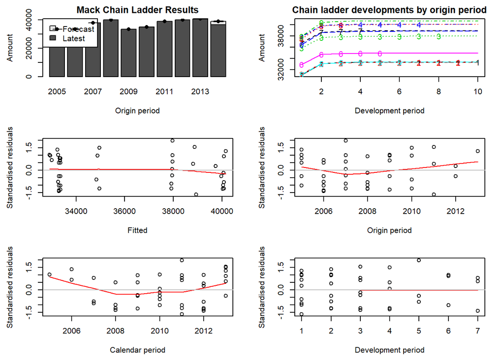

```r
plot(mack_ouv)
```

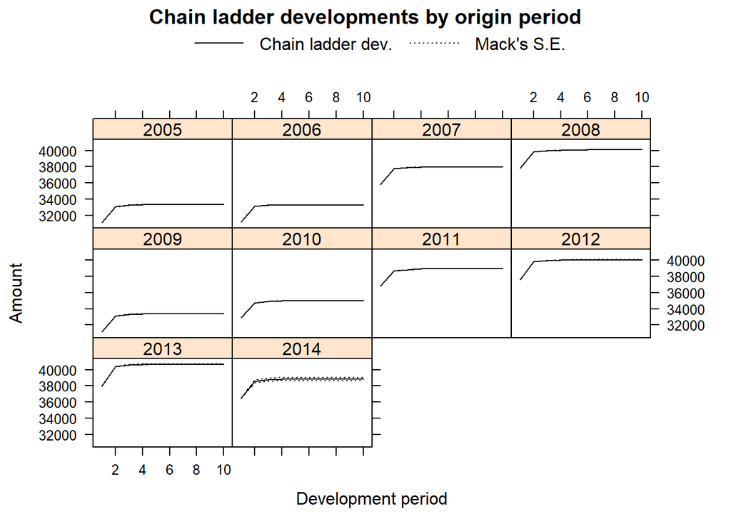

```r
plot(mack_ouv,lattice=TRUE)
```

On remarque dans ces courbes de developpements avec les erreurs estimées que l’erreur augmente de plus en plus qu’on avance dans les années de l’exercice ce qui est logique car plus on avance dans les années plus on a moins de données historiques (la variabilité est représentée numériquement par la variable “Mack.S.E” mentionnée en dessus).

## Triangle des règlements

On refait la même procédure avec le triangle de réglements

```r
mack_reg=suppressWarnings(MackChainLadder(tri_reg_cum,est.sigma = "Mack"))
mack_reg
```

```
## MackChainLadder(Triangle = tri_reg_cum, est.sigma = "Mack")
##
##          Latest Dev.To.Date   Ultimate       IBNR  Mack.S.E CV(IBNR)
## 2005  6,359,226       1.000  6,359,226          0         0      NaN
## 2006  6,156,665       0.997  6,174,778     18,113       656   0.0362
## 2007  7,696,706       0.996  7,724,636     27,930     6,442   0.2307
## 2008  8,497,101       0.982  8,649,070    151,969    61,011   0.4015
## 2009  9,521,143       0.977  9,747,917    226,774    69,989   0.3086
## 2010 10,784,701       0.963 11,200,820    416,119    92,012   0.2211
## 2011 12,882,218       0.937 13,741,975    859,757   131,047   0.1524
## 2012 14,344,968       0.879 16,318,504  1,973,536   400,742   0.2031
## 2013 11,791,984       0.708 16,656,384  4,864,400 1,108,134   0.2278
## 2014  2,045,751       0.156 13,142,632 11,096,881 1,691,054   0.1524
##
##                   Totals
## Latest:    90,080,463.00
## Dev:                0.82
## Ultimate: 109,715,940.70
## IBNR:      19,635,477.70
## Mack.S.E    2,206,637.23
## CV(IBNR):           0.11
```

Le retour de la méthode contient les éléments suivants:  
• Latest: c’est la valeur de la diagonale pour chaque ligne (ouvertures dont les dossiers sont ouverts dans la période de l’exercice).  
• Ultimate: c’est le nombre estimé des dossiers ouverts pour la durée d’exercice.  
• Dev.To.Dave : c’est la ratio Latest/Ultime.  
• IBNR: nombre ultime -> Ultimate - Latest.  
• Mack.S.E : variabilité de la projection de la méthode chainLadder, varie selon le nombre de projections (estimations) faites pour chaque année.

```r
print("facteurs de développement")
```

```
## [1] "facteurs de développement"
```

```r
mack_reg$f
```

```
##  [1] 4.548160 1.241690 1.066405 1.027110 1.014423 1.005829 1.014204 1.000685
##  [9] 1.002942 1.000000
```

On remarque qu’on obtient des fateurs de développements équvalentes à celle de chainLadder

```r
mack_reg$FullTriangle
```

```
##       dev
## origin       1        2        3        4        5        6        7        8
##   2005  932885  4170108  5178742  5895583  6101205  6142992  6201206  6339425
##   2006  754417  3466602  5314858  5765461  5929663  6059290  6091617  6149260
##   2007  978419  5103958  6778747  7246934  7464958  7583027  7609862  7696706
##   2008 1316441  6021787  7555658  8053228  8327443  8449896  8497101  8617797
##   2009 1515114  7237753  8623382  9198259  9396273  9521143  9576641  9712672
##   2010 2228111  8471438 10040083 10577748 10784701 10940245 11004015 11160321
##   2011 2444956 10146801 12415451 12882218 13231451 13422284 13500521 13692288
##   2012 2270648 11959204 14344968 15297548 15712260 15938873 16031779 16259501
##   2013 2591382 11791984 14641986 15614290 16037588 16268893 16363723 16596160
##   2014 2045751  9304403 11553181 12320372 12654374 12836884 12911709 13095112
##       dev
## origin        9       10
##   2005  6340572  6359226
##   2006  6156665  6174778
##   2007  7701977  7724636
##   2008  8623699  8649070
##   2009  9719323  9747917
##   2010 11167963 11200820
##   2011 13701664 13741975
##   2012 16270636 16318504
##   2013 16607525 16656384
##   2014 13104080 13142632
```

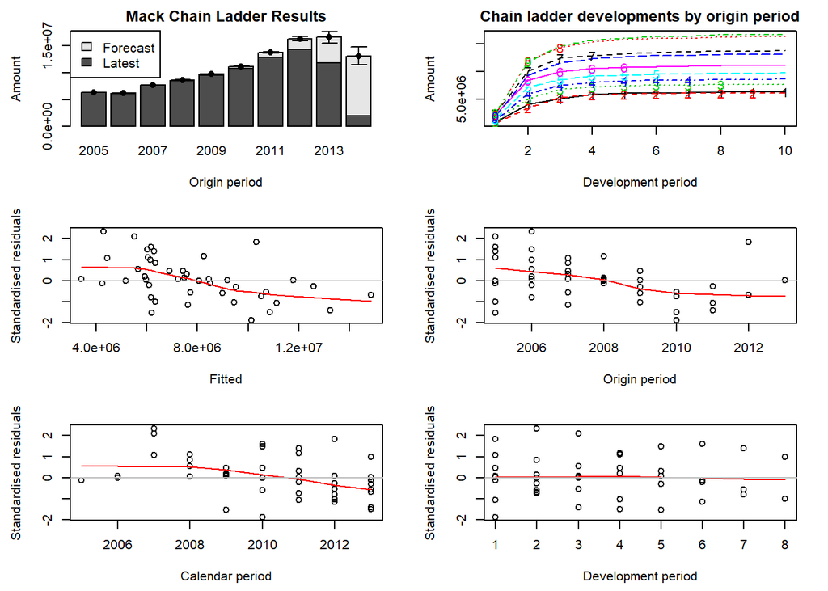

```r
plot(mack_reg)
```

Cette fois-ci les résidus présentent des tendance bien plus évidentes , ce qui nous mène à questionner la validité de cette méthode pour ce cas.

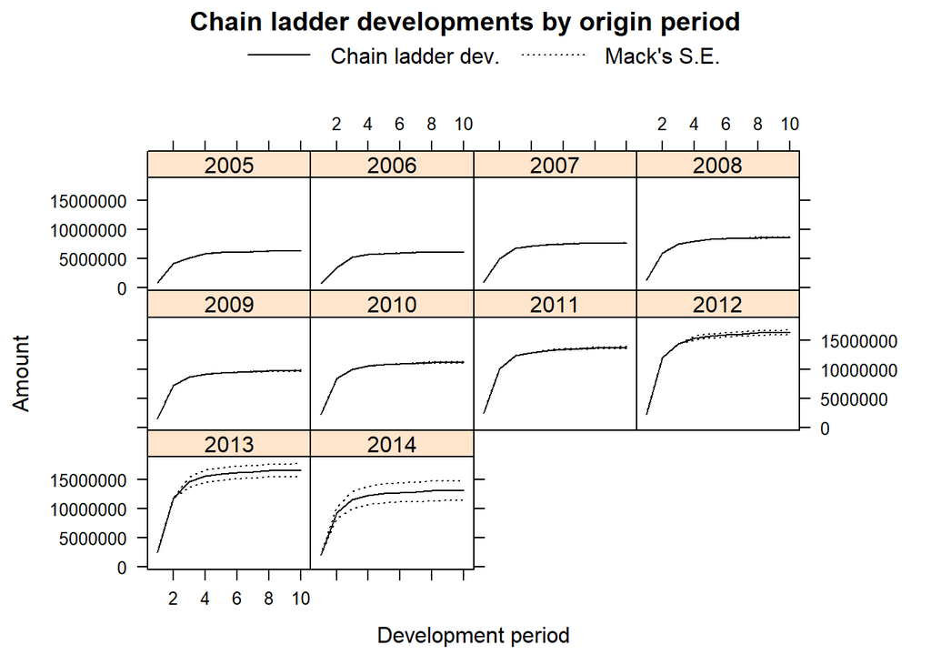

```r
plot(mack_reg,lattice=TRUE)
```

Même remarque plus on avance plus les données historiques diminuent et ainsi la marge d’erreur augmente

#Application de la méthode Bootstrap (Question 6) Bootstrap est aussi une méthode se basant sur ChainLadder en y ajoutant de l’aléa pour aboutir à des résultats plus fiables.

## Triangle d’ouvertures - bootstrap

```r
boot_ouv <- BootChainLadder(tri_ouv_cum, R=10000, process.distr="gamma")
boot_ouv
```

```
## BootChainLadder(Triangle = tri_ouv_cum, R = 10000, process.distr = "gamma")
##
##      Latest Mean Ultimate Mean IBNR IBNR.S.E IBNR 75% IBNR 95%
## 2005 33,362        33,362      0.00     0.00     0.00     0.00
## 2006 33,298        33,298      0.00     0.00     0.00     0.00
## 2007 37,976        37,976      0.00     0.00     0.00     0.00
## 2008 40,082        40,084      1.54     3.99     1.83     9.05
## 2009 33,362        33,365      3.11     5.30     4.56    13.23
## 2010 34,964        34,972      8.40     8.21    12.09    24.40
## 2011 38,908        38,929     21.45    13.01    28.61    45.92
## 2012 39,956        40,043     86.64    25.46   102.19   132.15
## 2013 40,400        40,669    268.81    43.67   297.00   342.76
## 2014 36,480        38,844  2,364.14   132.89 2,452.50 2,585.25
##
##                  Totals
## Latest:         368,788
## Mean Ultimate:  371,542
## Mean IBNR:        2,754
## IBNR.S.E            148
## Total IBNR 75%:   2,852
## Total IBNR 95%:   3,003
```

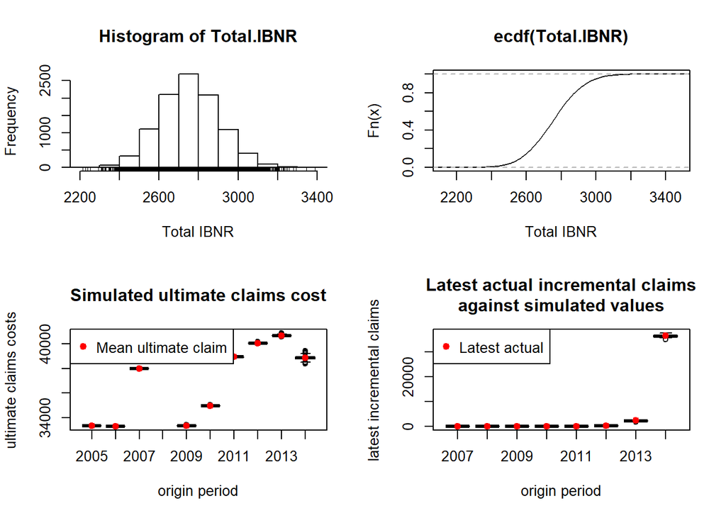

```r
plot(boot_ouv)
```

A partir des courbe de l’histogramme des des nombres ultimes (IBNR) et sa fonction de répartition on remarque qu’elle pourrait suive la loi log-normale.  
On remarque aussi des courbe de boites à moustaches que ,les variances des valeurs éstimées qui encore une fois sont distribuées sur un intervalle plus grand si on avance dans les années (la variabilité augmente proportionnellement aux années)

```r
#on peut essayer de comparer la courbe de répartition à la loi normale
plot(boot_ouv,which=2)
## fit a log-normal distribution
fit <- fitdistr(boot_ouv$IBNR.Totals[boot_ouv$IBNR.Totals>0], "lognormal")
fit
```

```
##      meanlog         sdlog
##   7.9194070966   0.0536399246
##  (0.0005363992) (0.0003792915)
```

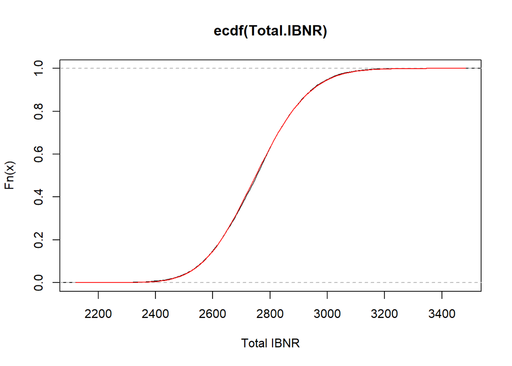

```r
curve(plnorm(x,fit$estimate["meanlog"], fit$estimate["sdlog"]),
col="red", add=TRUE)
```

## Triangle des règlements - Boostrap

```r
boot_reg <- BootChainLadder(tri_reg_cum, R=10000, process.distr="gamma")
boot_reg
```

```
## BootChainLadder(Triangle = tri_reg_cum, R = 10000, process.distr = "gamma")
##
##          Latest Mean Ultimate  Mean IBNR  IBNR.S.E   IBNR 75%   IBNR 95%
## 2005  6,359,226     6,359,226          0         0          0          0
## 2006  6,156,665     6,176,514     19,849    50,306     25,140    119,758
## 2007  7,696,706     7,727,116     30,410    67,658     47,842    154,075
## 2008  8,497,101     8,655,564    158,463   125,548    223,427    395,510
## 2009  9,521,143     9,757,478    236,335   151,079    318,764    519,848
## 2010 10,784,701    11,214,310    429,609   204,032    548,323    810,824
## 2011 12,882,218    13,758,150    875,932   288,747  1,052,338  1,389,431
## 2012 14,344,968    16,343,771  1,998,803   435,085  2,268,032  2,761,592
## 2013 11,791,984    16,695,202  4,903,218   719,733  5,354,694  6,149,000
## 2014  2,045,751    13,238,782 11,193,031 2,191,212 12,256,013 15,029,832
##
##                   Totals
## Latest:         9.01e+07
## Mean Ultimate:  1.10e+08
## Mean IBNR:      1.98e+07
## IBNR.S.E        2.59e+06
## Total IBNR 75%: 2.13e+07
## Total IBNR 95%: 2.44e+07
```

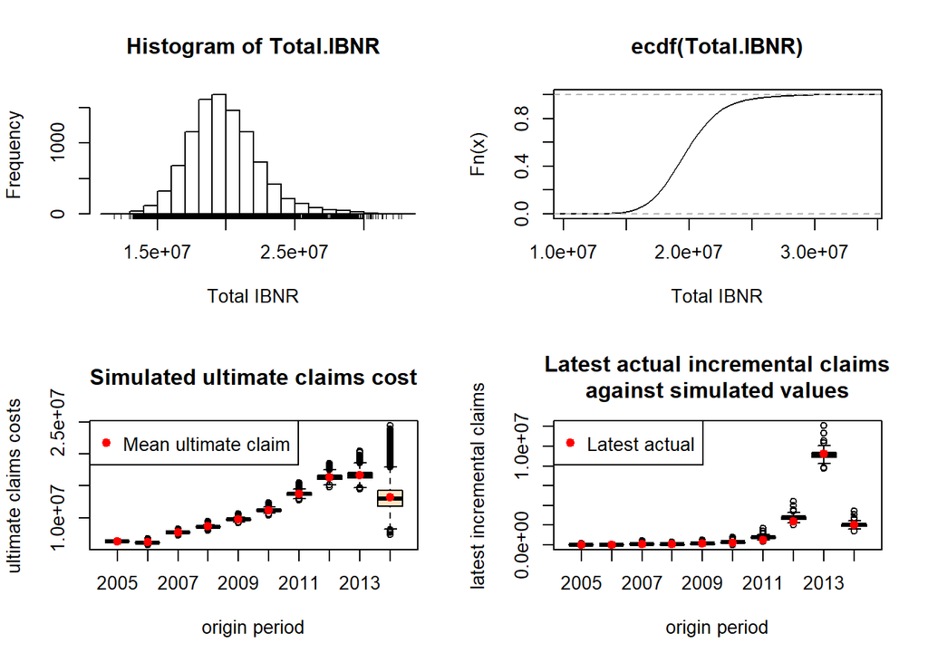

```r
plot(boot_reg)
```

De même la fonction de répartition des nombres ultimes (IBNR) suit une loi log-normale et les boîtes à moustaches présentents des valeurs qui sont plus variables en comparaison avec les boîtes à mosutaches des ovuertures, normalement à cause de la diffèrence des échèlles des valeurs éstimées.

```r
#on peut essayer de comparer la courbe de répartition à la loi normale
plot(boot_reg,which=2)
## fit a log-normal distribution
fit <- fitdistr(boot_reg$IBNR.Totals[boot_reg$IBNR.Totals>0], "lognormal")
fit
```

```
##      meanlog         sdlog
##   1.679524e+01   1.278573e-01
##  (1.278573e-03) (9.040873e-04)
```

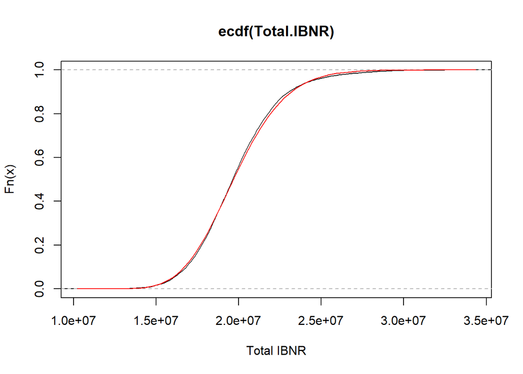

```r
curve(plnorm(x,fit$estimate["meanlog"], fit$estimate["sdlog"]),
col="red", add=TRUE)
```

Même remarque la fonction de répartition semble suivre la loi log-normale.  
#Question7: Intérprétations faîtes en parallèles avec les bout de codes. # Conclusion Après avoir eu recours aux différentes méthodes qui se basent sur ChainLadder, certains indices montrent que les hypothèses qu’on a supposé valides ne le sont peut-être pas.  
Faut penser à lisser nos facteurs de développements.